# BioBuilder Code

# Assessment of $\beta$-gal Activity

## Introduction

The Biobuilder iTune Device lab guides you through measurement of the activity of the *lacZ* gene produce known as $\beta$-galactosidase or $\beta$-gal for short. The activity level of $\beta$-gal represents the combined effectiveness of promoter and ribosome binding site (RBS) pairs. Weak combinations produce relatively low levels of $\beta$-gal while strong pairs produce relatively high levels of $\beta$-gal. In this way, the $\beta$-gal measurement is a measure of performance.

Performance is measured as the level of yellow color which is produced when $\beta$-gal cleaves a substrate called [ortho-Nitrophenyl-β-galactoside](https://en.wikipedia.org/wiki/Ortho-Nitrophenyl-%CE%B2-galactoside) (ONPG). $\beta$-gal cleaves ONPG into two components: o-nitrophenol and galactose. While the galactose is colorless, the o-nitrophenol is yellow, which provides a visible signal for $\beta$-gal activity. A more-yellow color indicates a more-active $\beta$-gal system.

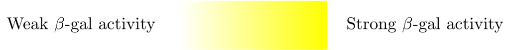

## Getting Started

The iTune Device activity uses ten strains for testing. For each strain, you will grow a liquid culture using [LB growth media](https://en.wikipedia.org/wiki/Lysogeny_broth), ampicillin (for [selection of the plasmid](https://www.addgene.org/mol-bio-reference/#antibiotics) carrying the correct promoter:RBS:lacZ construct), and [isopropyl β- d-1-thiogalactopyranoside](https://en.wikipedia.org/wiki/Isopropyl_%CE%B2-D-1-thiogalactopyranoside) (IPTG) to relieve inhibition of the lacZ gene.

| Strain # | Registry # (promoter part) | Registry # (RBS part) | Relative Strength (promoter/RBS) |
| --- | --- | --- | --- |
| 2-R | BBa_J23115 | BBa_B0035 | Reference/reference |
| 2-1 | BBa_J23113 | BBa_B0031 | Weak/weak |
| 2-2 | BBa_J23113 | BBa_B0032 | Weak/medium |
| 2-3 | BBa_J23113 | BBa_B0034 | Weak/strong |
| 2-4 | BBa_J23106 | BBa_B0031 | Medium/weak |
| 2-5 | BBa_J23106 | BBa_B0032 | Medium/medium |
| 2-6 | BBa_J23106 | BBa_B0034 | Medium/strong |
| 2-7 | BBa_J23119 | BBa_B0031 | Strong/weak |
| 2-8 | BBa_J23119 | BBa_B0032 | Strong/medium |
| 2-9 | BBa_J23119 | BBa_B0034 | Strong/strong |

## Measurement

The activity of $\beta$-gal will be quantified using Miller Units which are calculated as follows.

> Activity (Miller Units) = $1000 \cdot \frac{Abs420}{T \cdot V \cdot OD600}$

where A represents $\beta$-gal activity, Abs420 represents the measured sample asborption at 420nm in a spectrophotometer, T represents the reaction time (minutes), V represents the volume of cells in each reaction (ml), and OD600 represents the sample optical density at 600nm in a spectrophotometer.

### Miller Units Calculation

The Miller Units can be calculated using the formula. Replace the values with your own to calculate your specific $\beta$-gal activity level.

```r
abs420<-0.73 #usually 0.05 to 1; ideally 0.6 to 0.9
abs600<-0.52 #usually 0.28 to 0.70
v<-0.02      #volume in ml
t<-150       #time in minutes

#miller units
mu<-1000*(abs420/(t*v*abs600))
```

```
## Activity =  467.9487 Miller Units
```

The increase in Miller Units as Abs420 increases can be seen in this simulation. Note the linear relationship.

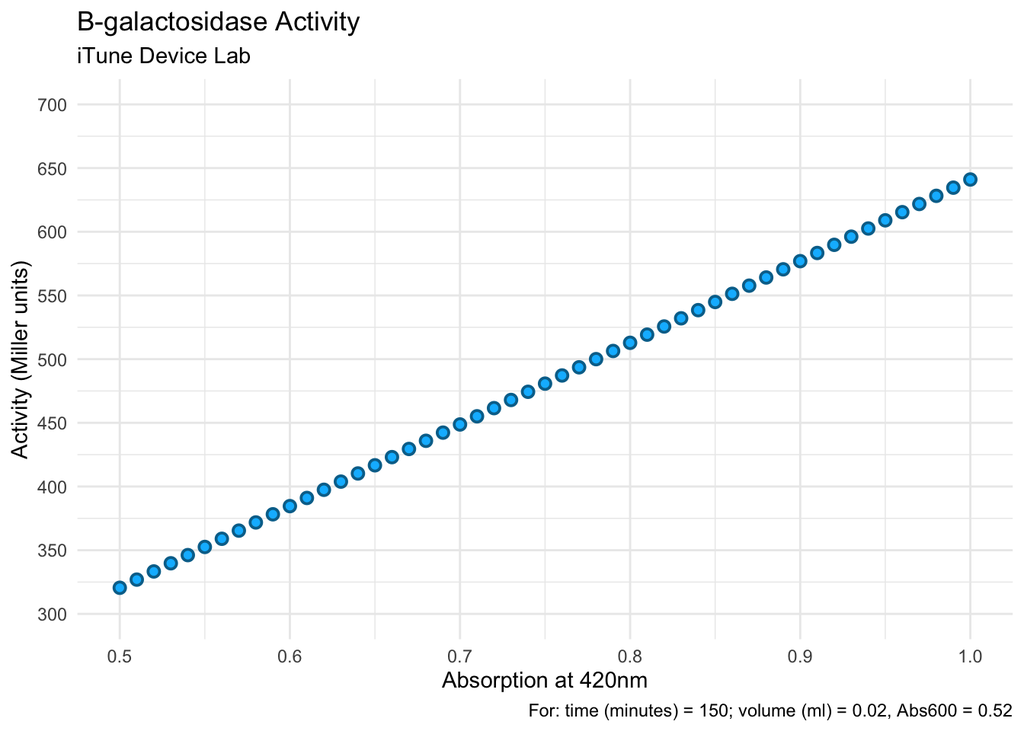

```r
abs420<-seq(0.5,1.0,by=0.01)
t<-150
v<-0.02
abs600<-0.52

#activity calculation function
mu <- function(abs420,t,v,abs600) {
  output <- 1000*(abs420/(t*v*abs600))
  return(output)
}

#run the function for values of the sequence
activity<-mu(abs420,t,v,abs600)

#create a data frame
df<-data.frame(abs420,activity)

ggplot(df, aes(x=abs420,y=activity)) +
  geom_point(shape = 21, colour = "#007099", fill = "#00BBFF", size = 2, stroke = 1)+
  scale_y_continuous(limits=c(300,700), breaks=seq(300,700,by=50))+
  labs(x="Absorption at 420nm", y="Activity (Miller units)",title="B-galactosidase Activity", subtitle="iTune Device Lab", caption="For: time (minutes) = 150; volume (ml) = 0.02, Abs600 = 0.52")+
  theme_minimal()+
  theme(legend.position = "none")
```